# Review

NU Social Science Math Camp

## Agenda

- **Morning:** Further learning and review
- **Lunch:** Meet grad students on the market
- **Afternoon:** Markdown

# Further learning

## Math camp reference

[figure not shown]

doi.org/10.1017/CBO9780511606656 (free via NU Library)

## Math camp reference

[figure not shown]

**Website:** www.daveasiegel.com/teaching/math-course/

**Youtube:** www.youtube.com/c/DavidSiegelmath/playlists

## Tidyverse

**Book:** r4ds.hadley.nz

**Short guides:** posit.cloud/learn/recipes

**Cheatsheets:** posit.co/resources/cheatsheets/

## Textbooks

[figure not shown]

## Textbooks

[figure not shown]

## Textbooks

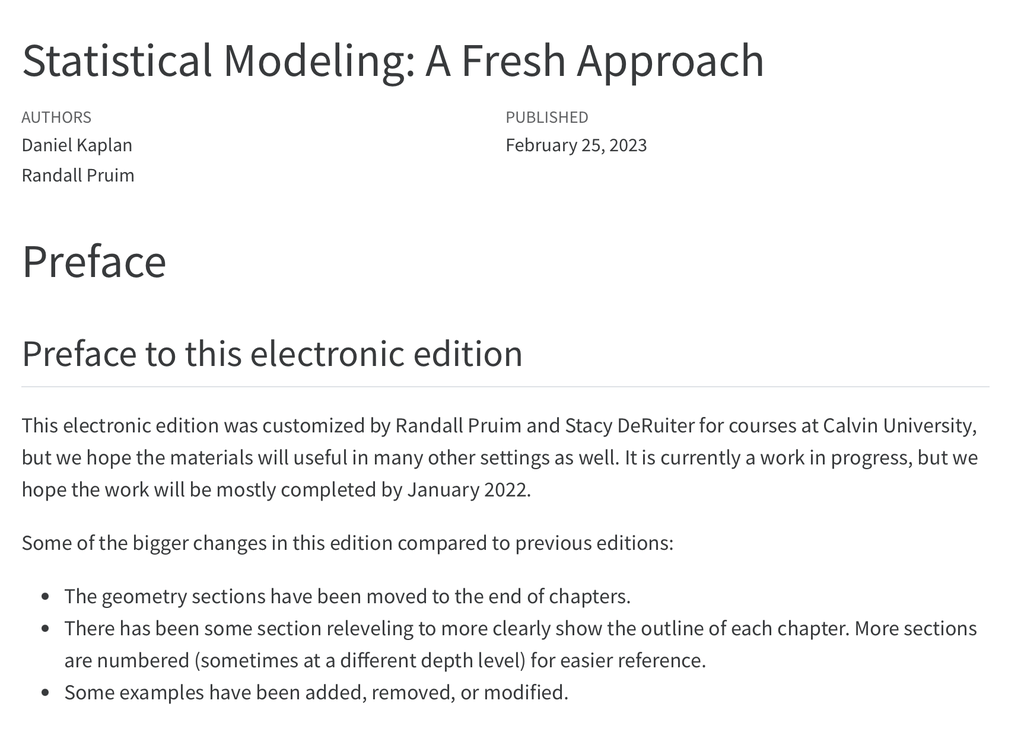

statistical-modeling.netlify.app

## Courses in Political Science

**Core sequence:** Prob & Stats, Linear Models, Causal Inference

**2026-27 Electives**

- Small N (F)
- Experiments (S)

## Courses in Sociology

**Core sequence:** Stats & Software, Linear Regression, Categorical Regression

**2026-27 Electives**

- Small N (F)
- Content Analysis (W)
- Qualitative Data Collection (S)
- Survey Design and Analysis (S)

## Year-long workshops

**SOCIOL 576:** Quantitative and Computational Methods Workshop

**POLI_SCI 490:** Statistical Computing Workshop

- .33 credit each quarter
- Can participate in both without getting credit

## Ad-hoc MS in Applied Statistics

- 9 courses + culminating project
- Statistical Theory and Methods sequence required (STAT 320-1 and -2)
- **Concentration:** Stats only, data science, outside course
- Apply before or shortly after taking courses
- Awarded simultaneously with PhD

statistics.northwestern.edu/graduate/ad-hoc-ms-degree/

# Questions?

## How much of math camp will matter?

**Math**

- Mostly at a conceptual level (unless you do formal theory)
- Confidence in *soft* skills

**R**

- Solid foundation to stay up to date with both coding and methods
- Easy to learn Python later if you need to